# Central Limit Theorem - P1

Rohit Tolawat

6/12/2020

```r
pacman::p_load(caret, data.table, ggplot2, dplyr)
knitr::opts_chunk$set(echo = FALSE, fig.width=12, fig.height=6, fig.path = 'Figs/')
options(digits = 3)
```

#Reading the hospital datasheet

```
## [1] 101766     50
```

```
##   encounter_id patient_nbr            race gender     age weight
## 1      2278392     8222157       Caucasian Female  [0-10)      ?
## 2       149190    55629189       Caucasian Female [10-20)      ?
## 3        64410    86047875 AfricanAmerican Female [20-30)      ?
## 4       500364    82442376       Caucasian   Male [30-40)      ?
## 5        16680    42519267       Caucasian   Male [40-50)      ?
## 6        35754    82637451       Caucasian   Male [50-60)      ?
##   admission_type_id discharge_disposition_id admission_source_id
## 1                 6                       25                   1
## 2                 1                        1                   7
## 3                 1                        1                   7
## 4                 1                        1                   7
## 5                 1                        1                   7
## 6                 2                        1                   2
##   time_in_hospital payer_code        medical_specialty num_lab_procedures
```

[output cut: 55 more lines]

#Isolating the time in hospital column for better understanding and manipulation

```
## [1] 0
```

#Checking the distribution of the population and the mean days spent by a patient in hospital

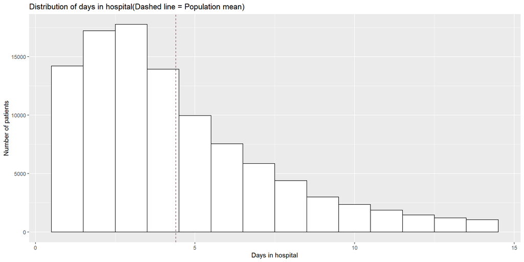

#Insight corner: Most patients are discharged in less than 5 days, the distributed is right-skewed

#Taking 1000 samples of size 2,10,20 and 40 from the population

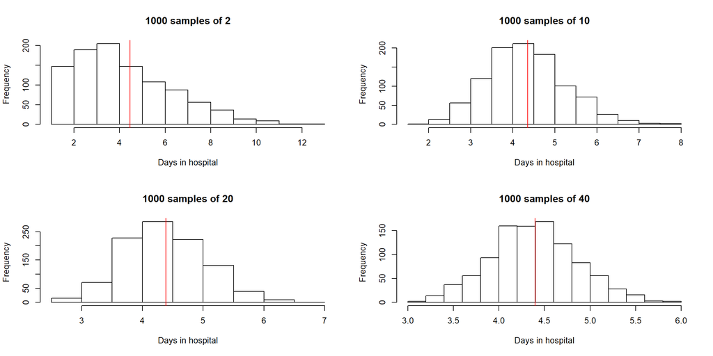

#Insight corner: Sampling distribution of sample means attains normal distriburion as sample size increases

```
##    sample_size sample_mean sample_sd
## 1:           2        4.45     2.134
## 2:          10        4.35     0.926
## 3:          20        4.39     0.665
## 4:          40        4.40     0.473
```

#Plotting standard deviation against sample size

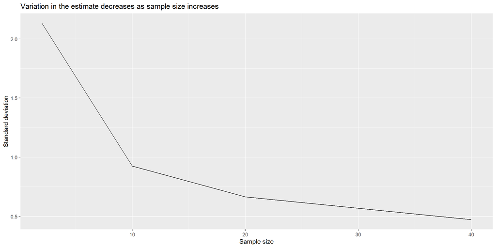

#Plotting estimate of the mean against sample size

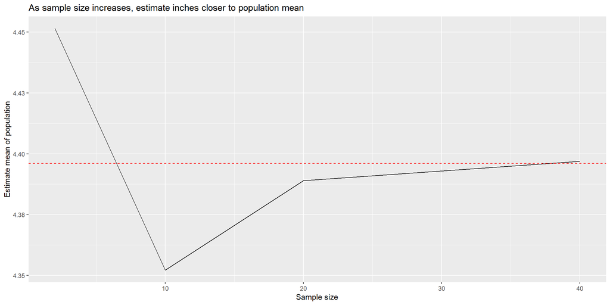

# Central Limit Theorem - P1

Rohit Tolawat

6/12/2020

```r
pacman::p_load(caret, data.table, ggplot2, dplyr)
knitr::opts_chunk$set(echo = FALSE, fig.width=12, fig.height=6, fig.path = 'Figs/')
options(digits = 3)
```

#Reading the hospital datasheet

```
## [1] 101766     50
```

```
##   encounter_id patient_nbr            race gender     age weight
## 1      2278392     8222157       Caucasian Female  [0-10)      ?
## 2       149190    55629189       Caucasian Female [10-20)      ?
## 3        64410    86047875 AfricanAmerican Female [20-30)      ?
## 4       500364    82442376       Caucasian   Male [30-40)      ?
## 5        16680    42519267       Caucasian   Male [40-50)      ?
## 6        35754    82637451       Caucasian   Male [50-60)      ?
##   admission_type_id discharge_disposition_id admission_source_id
## 1                 6                       25                   1
## 2                 1                        1                   7
## 3                 1                        1                   7
## 4                 1                        1                   7
## 5                 1                        1                   7
## 6                 2                        1                   2
##   time_in_hospital payer_code        medical_specialty num_lab_procedures
```

[output cut: 55 more lines]

#Isolating the time in hospital column for better understanding and manipulation

```
## [1] 0
```

#Checking the distribution of the population and the mean days spent by a patient in hospital

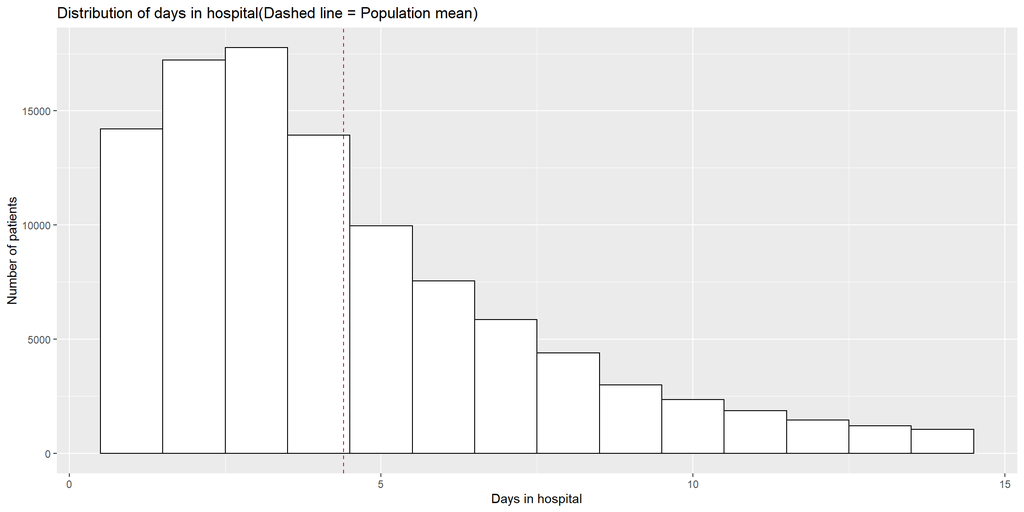

#Insight corner: Most patients are discharged in less than 5 days, the distributed is right-skewed

#Taking 1000 samples of size 2,10,20 and 40 from the population

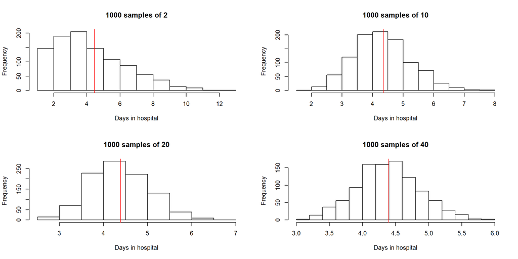

#Insight corner: Sampling distribution of sample means attains normal distriburion as sample size increases

```
##    sample_size sample_mean sample_sd
## 1:           2        4.45     2.134
## 2:          10        4.35     0.926
## 3:          20        4.39     0.665
## 4:          40        4.40     0.473
```

#Plotting standard deviation against sample size

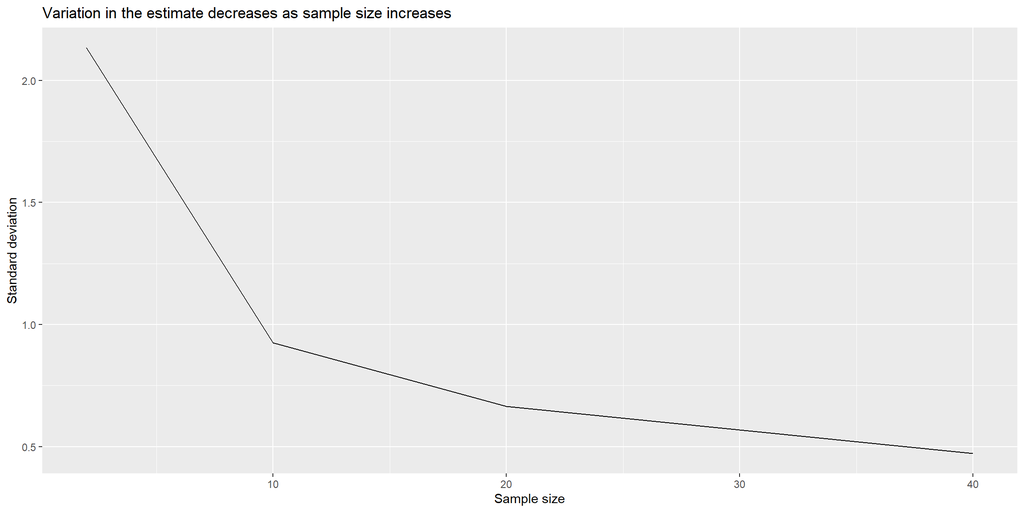

#Plotting estimate of the mean against sample size

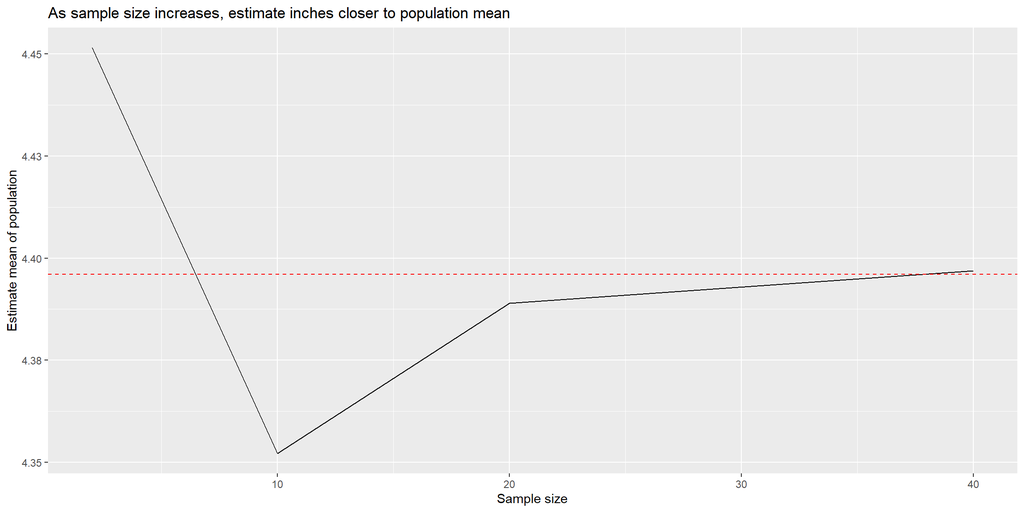